# Chicago Crimes

Rahul Jadhav

2/16/2022

## DATA PREPARATION

For Data Preparation here we are going to merge related Crime Time, Create Indicator variables for Arrests and Domestics, Create Month, Day and Time variable from Date Variables.We also converted all character variables to factor variables

```r
main_dataset <- read.csv("Chicago_Crimes_2001_to_2017_Part2.csv")

cleaned_data <- main_dataset %>%
  mutate(
    Primary.Type = ifelse(Primary.Type=="HOMICIDE","HOMICIDE",
                          ifelse(Primary.Type=="CRIM SEXUAL ASSAULT" |
                                   Primary.Type=="SEX OFFENSE" , "SEXUAL OFFENCE",
                                 ifelse(Primary.Type == "ASSAULT","ASSAULT",
                                        ifelse(Primary.Type == "ROBBERY", "ROBBERY",
                                               ifelse(Primary.Type == "NON-CRIMINAL" |
                                                        Primary.Type == "NON - CRIMINAL" |
                                                        Primary.Type == "NON-CRIMINAL (SUBJECT SPECIFIED)", "NON-CRIMINAL",
                                                      main_dataset$Primary.Type)
                                               )
                                        )
                                 )
                          ),
    Arrest = ifelse(
      Arrest == "False" | Arrest == "FALSE", 0 , 1),
    Domestic = ifelse(
      Domestic == "False" | Domestic == "FALSE", 0, 1),
    Date = as.POSIXlt(Date, format = "%m/%d/%Y %I:%M:%S %p")
  ) %>%
  sample_n(20000,replace = FALSE) %>%
  select(-c(X.1,X,ID,Case.Number,Updated.On,Location,IUCR,Beat,X.Coordinate,Y.Coordinate))

cleaned_data <- cleaned_data %>%
  mutate(
    Month = format(cleaned_data$Date, format="%m"),
    Day = format(cleaned_data$Date, format="%d"),
    Time = format(cleaned_data$Date, format="%H")
  )


cleaned_data[sapply(cleaned_data, is.character)] <- lapply(
  cleaned_data[sapply(
    cleaned_data,
    is.character)]
  ,as.factor)

character_dataset <- cleaned_data[sapply(cleaned_data, is.factor)]
```

## Summary Statistics

```r
## Frequency Distribution of Primary Type and arrests
library("gmodels")
CrossTable(cleaned_data$Primary.Type, cleaned_data$Arrest,prop.t=FALSE, prop.r=FALSE, prop.c=FALSE,prop.chisq=FALSE)
```

```
##
##
##    Cell Contents
## |-------------------------|
## |                       N |
## |-------------------------|
##
##
## Total Observations in Table:  20000
##
##
##                                  | cleaned_data$Arrest
##        cleaned_data$Primary.Type |         0 |         1 | Row Total |
## ---------------------------------|-----------|-----------|-----------|
##                            ARSON |        24 |         6 |        30 |
## ---------------------------------|-----------|-----------|-----------|
##                          ASSAULT |       957 |       275 |      1232 |
## ---------------------------------|-----------|-----------|-----------|
##                          BATTERY |      2830 |       853 |      3683 |
## ---------------------------------|-----------|-----------|-----------|
##                         BURGLARY |      1103 |        75 |      1178 |
## ---------------------------------|-----------|-----------|-----------|
##                  CRIMINAL DAMAGE |      2073 |       142 |      2215 |
## ---------------------------------|-----------|-----------|-----------|
##                CRIMINAL TRESPASS |       142 |       414 |       556 |
## ---------------------------------|-----------|-----------|-----------|
##               DECEPTIVE PRACTICE |       585 |       134 |       719 |
## ---------------------------------|-----------|-----------|-----------|
##                         GAMBLING |         0 |        52 |        52 |
## ---------------------------------|-----------|-----------|-----------|
##                         HOMICIDE |        11 |        12 |        23 |
## ---------------------------------|-----------|-----------|-----------|
## INTERFERENCE WITH PUBLIC OFFICER |         3 |        39 |        42 |
## ---------------------------------|-----------|-----------|-----------|
##                     INTIMIDATION |        13 |         2 |        15 |
## ---------------------------------|-----------|-----------|-----------|
##                       KIDNAPPING |        11 |         4 |        15 |
## ---------------------------------|-----------|-----------|-----------|
##             LIQUOR LAW VIOLATION |         0 |        37 |        37 |
## ---------------------------------|-----------|-----------|-----------|
```

[output cut: 13 more lines]

```
## ---------------------------------|-----------|-----------|-----------|
##                          ROBBERY |       701 |        91 |       792 |
## ---------------------------------|-----------|-----------|-----------|
##                   SEXUAL OFFENCE |       127 |        29 |       156 |
## ---------------------------------|-----------|-----------|-----------|
##                         STALKING |        12 |         4 |        16 |
## ---------------------------------|-----------|-----------|-----------|
##                            THEFT |      3660 |       496 |      4156 |
## ---------------------------------|-----------|-----------|-----------|
##                WEAPONS VIOLATION |        40 |       165 |       205 |
## ---------------------------------|-----------|-----------|-----------|
##                     Column Total |     14304 |      5696 |     20000 |
## ---------------------------------|-----------|-----------|-----------|
##
##
```

```r
summary(character_dataset)
```

```
##                   Block                Primary.Type
##  100XX W OHARE ST    :   63   THEFT          :4156
##  001XX N STATE ST    :   28   BATTERY        :3683
##  0000X N STATE ST    :   26   NARCOTICS      :2246
##  023XX S STATE ST    :   25   CRIMINAL DAMAGE:2215
##  076XX S CICERO AVE  :   25   ASSAULT        :1232
##  008XX N MICHIGAN AVE:   18   OTHER OFFENSE  :1220
##  (Other)             :19815   (Other)        :5248
##                   Description                        Location.Description
##  SIMPLE                 : 2344   STREET                        :5271
##  DOMESTIC BATTERY SIMPLE: 1558   RESIDENCE                     :3389
##  $500 AND UNDER         : 1549   SIDEWALK                      :2101
##  TO VEHICLE             : 1082   APARTMENT                     :1995
##  OVER $500              : 1047   OTHER                         : 746
##  TO PROPERTY            :  984   PARKING LOT/GARAGE(NON.RESID.): 548
##  (Other)                :11436   (Other)                       :5950
##     FBI.Code      Parts           Month           Day             Time
##  06     :4156   Part2:20000   07     :1865   01     :  722   20     : 1177
##  08B    :3150                 08     :1829   02     :  711   00     : 1166
##  14     :2215                 05     :1794   13     :  708   12     : 1148
##  18     :2099                 06     :1748   12     :  688   19     : 1139
##  26     :2040                 10     :1740   21     :  687   22     : 1136
##  05     :1178                 09     :1728   05     :  678   15     : 1088
##  (Other):5162                 (Other):9296   (Other):15806   (Other):13146
```

From the cross tabulation table we can observe the cross tabulatation between Primary type of crime cases and Arrests. We can also see the summary of factor variables which show us how many observations belongs to various types in variables.

## BASIC ANALYSIS

### Crime based on FBI Code

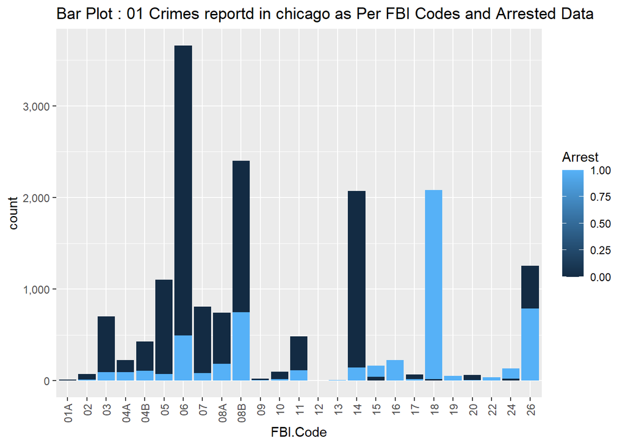

```r
library(dplyr)
library(ggplot2)
library(scales)
group_by_primary_type <- cleaned_data %>%
  group_by(FBI.Code,Arrest) %>%
  summarise(count = n())%>%
  mutate(
    porportion = round(count/sum(count),2),
    percentage = round((count/sum(count)*100),2)
  ) %>%
  arrange(desc(percentage))
ggplot(group_by_primary_type,aes(x=FBI.Code,y=count,fill= Arrest))+
  geom_bar(position="dodge", stat="identity")+
  theme(axis.text.x = element_text(angle = 90, vjust = 0.5, hjust=1))+
  scale_y_continuous(label = comma)+
  ggtitle("Bar Plot : 01 Crimes reportd in chicago as Per FBI Codes and Arrested Data")
```

From the above plot we can see that cases belonging to FBI Code 06 are reported more followed by 08B. if observed properly cases belonging to FBI code 18 and 16 have more arrests in respective to the cases been reported.

### Year-Wise Crime rate

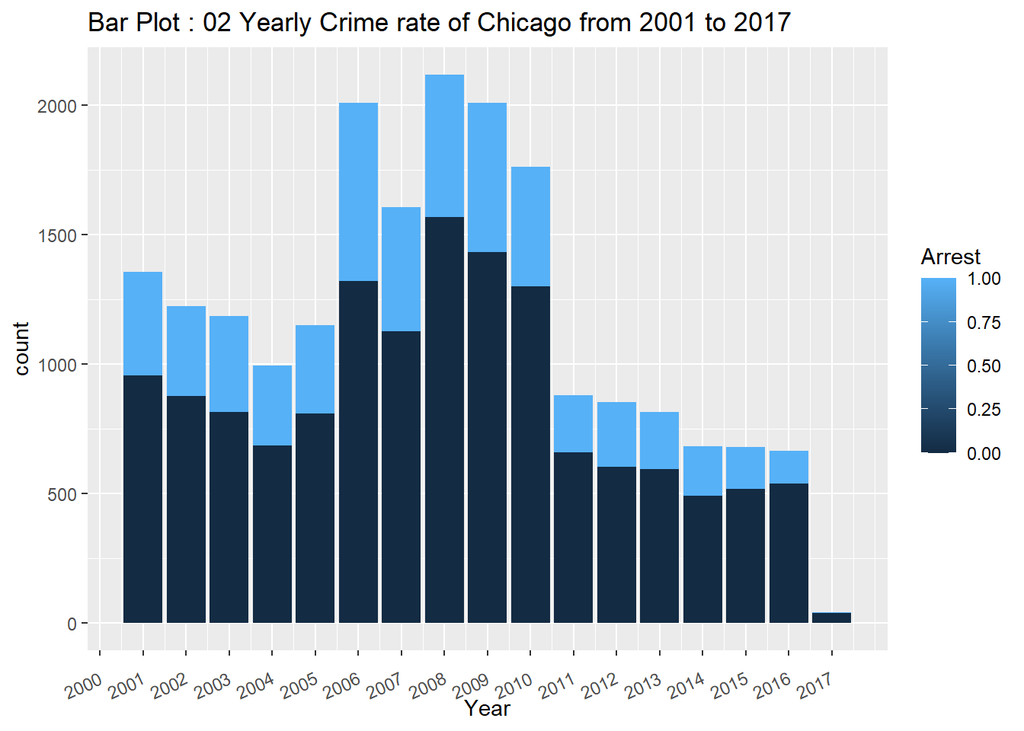

```r
library(dplyr)
library(ggplot2)
group_by_Year <- cleaned_data %>%
  group_by(Year,Arrest) %>%
  summarise(count = n()) %>%
  mutate(
    porportion = round(count/sum(count),2),
    percentage = round((count/sum(count)*100),2)
  ) %>%
  arrange((Year))
ggplot(group_by_Year,aes(x=Year,y=count, fill= Arrest))+
  geom_bar(stat="identity")+
  theme(axis.text.x = element_text(angle = 25, vjust = 0.5, hjust=1))+
  ggtitle("Bar Plot : 02 Yearly Crime rate of Chicago from 2001 to 2017")+
  scale_x_continuous(breaks = 2000:2017)
```

- From the above plot we can see that the crime rate is in decreasing trend after the year 2008.
- We can also observe that from 2014 to 2016 the arrest rate have decreased.